# Homework12

Bailey Kretzler

4/28/2021

### Introduction

Today I am going to be making some graphs! I have some bean root data I want to look at so lets make some root length graphs. One thing I want to know is is root length differs between genotype and treatment. For this I’ll do a basic anova, tukey test, and then create a box plot. This data set is not complete and will eventually have the total water use of the plants, which I will test for correlation to root length. For now I will use root surface area as a stand in. I will create a linear model to determine if the relationship between these two variables is significant and then generate a scatterplot.

First let’s input the preliminaries

```r
#---------------------------------------------------------#
#                      Prelims
#---------------------------------------------------------#

#load in these packages
library(MASS)

library(ggplot2)

library(agricolae)
#---------------------------------------------------------#
#                      load in data
#---------------------------------------------------------#


df <- read.table(file = "CleanedWin.csv", sep = ",", header = TRUE)  #root scan data

colnames(df)
```

```
##  [1] "X"                    "SampleID"             "Part"
##  [4] "AnalysedRegionArea"   "AnalysedRegionWidth"  "AnalysedRegionHeight"
##  [7] "Length"               "ProjArea"             "SurfArea"
## [10] "AvgDiam"              "LenPerVol"            "RootVolume.cm3."
## [13] "Tips"                 "Forks"                "Crossings"
## [16] "NofNodules"           "NumberOfClasses"      "L0_0.5"
## [19] "L0.5_1.0"             "L1.0_1.5"             "L1.5_2.0"
## [22] "L2.0_2.5"             "L2.5_3.0"             "L3.0_3.5"
## [25] "L3.5_4.0"             "L4.0_4.5"             "L_4.5"
## [28] "SA0_0.5"              "SA0.5_1.0"            "SA1.0_1.5"
## [31] "SA1.5_2.0"            "SA2.0_2.5"            "SA2.5_3.0"
## [34] "SA3.0_3.5"            "SA3.5_4.0"            "SA4.0_4.5"
## [37] "SA4.5"                "PA0_0.5"              "PA0.5_1.0"
## [40] "PA1.0_1.5"            "PA1.5_2.0"            "PA2.0_2.5"
## [43] "PA2.5_3.0"            "PA3.0_3.5"            "PA3.5_4.0"
## [46] "PA4.0_4.5"            "PA4.5"                "V0_0.5"
## [49] "V0.5_1.0"             "V1.0_1.5"             "V1.5_2.0"
## [52] "V2.0_2.5"             "V2.5_3.0"             "V3.0_3.5"
## [55] "V3.5_4.0"             "V4.0_4.5"             "V.4.5"
## [58] "T0_0.5"               "T0.5_1.0"             "T1.0_1.5"
## [61] "T1.5_2.0"             "T2.0_2.5"             "T2.5_3.0"
## [64] "T3.0_3.5"             "T3.5_4.0"             "T4.0_4.5"
## [67] "T4.5"                 "GT"                   "TMT"
## [70] "rep"
```

```r
#subsetting to the most relevant data
Roots <- (df[,c("SampleID","GT", "TMT", "rep","Length", "SurfArea", "Tips", "Forks")])
```

### Boxplot

Now we can do the analysis for the box plot. I’m not using a function because this is pretty simple as is and I only have to do it once.

```r
#---------------------------------------------------------#
#                      analysis
#---------------------------------------------------------#

anova(lm(data = df, Length~GT*TMT)) #TMT is not significant let's take it out
```

```
## Analysis of Variance Table
##
## Response: Length
##           Df    Sum Sq  Mean Sq F value   Pr(>F)
## GT         5 259859547 51971909  3.6941 0.007661 **
## TMT        3   3070653  1023551  0.0728 0.974238
## GT:TMT    15 127225964  8481731  0.6029 0.854865
## Residuals 40 562754709 14068868
## ---
## Signif. codes:  0 '***' 0.001 '**' 0.01 '*' 0.05 '.' 0.1 ' ' 1
```

```r
anova(lm(data = df, Length~GT))# root lenth differs between genotypes
```

```
## Analysis of Variance Table
##
## Response: Length
##           Df    Sum Sq  Mean Sq F value   Pr(>F)
## GT         5 259859547 51971909  4.3494 0.001982 **
## Residuals 58 693051325 11949161
## ---
## Signif. codes:  0 '***' 0.001 '**' 0.01 '*' 0.05 '.' 0.1 ' ' 1
```

```r
t1 <- HSD.test(aov(data = Roots, Length~GT), "GT",console = TRUE)[[5]]
```

```
##
## Study: aov(data = Roots, Length ~ GT) ~ "GT"
##
## HSD Test for Length
##
## Mean Square Error:  11949161
##
## GT,  means
##
##             Length      std  r      Min       Max
## PI136687  7281.090 1337.213 12 4096.901  8924.220
## PI281999 10003.325 4662.190 12 2506.952 22464.107
## PI313250  9219.229 4053.115  4 4741.200 14587.938
## PI313307 10664.814 4857.578 12 3335.664 19289.066
## PI535413  5232.181 2170.498 12 1541.703  8474.296
## PI535447  6630.263 2587.102 12 1526.466 10996.023
##
## Alpha: 0.05 ; DF Error: 58
## Critical Value of Studentized Range: 4.167841
##
## Groups according to probability of means differences and alpha level( 0.05 )
##
## Treatments with the same letter are not significantly different.
##
##             Length groups
## PI313307 10664.814      a
## PI281999 10003.325      a
## PI313250  9219.229     ab
## PI136687  7281.090     ab
## PI535447  6630.263     ab
## PI535413  5232.181      b
```

```r
t1$ID <- rownames(t1)

head(t1)
```

```
##             Length groups       ID
## PI313307 10664.814      a PI313307
## PI281999 10003.325      a PI281999
## PI313250  9219.229     ab PI313250
## PI136687  7281.090     ab PI136687
## PI535447  6630.263     ab PI535447
## PI535413  5232.181      b PI535413
```

From the anovas we learn that treatment is not impacting root length, nor is the impact of the treatment different between genotypes. However, genotypes do differ in their total root length. Let’s make a graph of that. We will make a boxplot and include the ranks from the tukey test to add letters of significant difference.

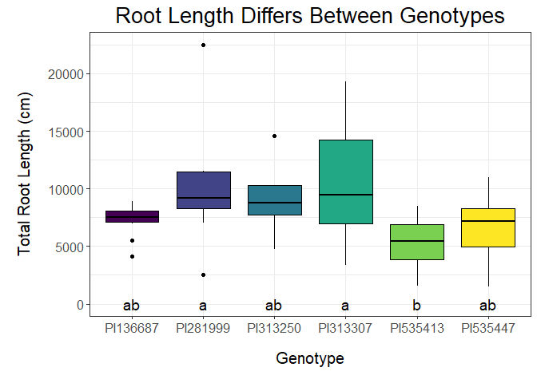

```r
#---------------------------------------------------------#
#                      graphs
#---------------------------------------------------------#


ggplot() +  geom_boxplot(data = Roots, aes(x = GT, y = Length, fill = GT), colour = "Black") +
  theme_bw() +
  ggtitle("Root Length Differs Between Genotypes") +
  xlab("Genotype") + ylab("Total Root Length (cm)") +
  geom_text(data = t1, aes(x = ID, y = 25, label = groups), size = 5) +
  theme(axis.text.x = element_text( size = 12),
        axis.text.y = element_text( size = 12),
        legend.position = "none",
        axis.title.x = element_text(size = 15, margin = margin(t = 15, r = 0, b = 10, l = 0)),
        axis.title.y = element_text(size = 15, margin = margin(t = 0, r = 15, b = 0, l = 10)),
        plot.title = element_text(size = 20, lineheight = 1.1, hjust = 0.5)) +
  scale_fill_viridis_d()
```

Nice! I think it’s a pretty good looking graph! Now for the scatter plot.

### Scatter Plot

Let’s start again with the data anlaysis. For the scatter plot we need to use a linear model. We should also check if treatment or genotype is impacting this relationship.

```r
#---------------------------------------------------------#
#                      analysis
#---------------------------------------------------------#

summary(lm(data = df, Length~SurfArea)) #relationship is significant
```

```
##
## Call:
## lm(formula = Length ~ SurfArea, data = df)
##
## Residuals:
##     Min      1Q  Median      3Q     Max
## -3470.4  -801.0    24.0   804.8  4002.1
##
## Coefficients:
##              Estimate Std. Error t value Pr(>|t|)
## (Intercept) 1224.9486   373.6530   3.278  0.00171 **
## SurfArea       4.6719     0.2264  20.636  < 2e-16 ***
## ---
## Signif. codes:  0 '***' 0.001 '**' 0.01 '*' 0.05 '.' 0.1 ' ' 1
##
## Residual standard error: 1398 on 62 degrees of freedom
## Multiple R-squared:  0.8729, Adjusted R-squared:  0.8709
## F-statistic: 425.8 on 1 and 62 DF,  p-value: < 2.2e-16
```

```r
anova(lm(data = df, Length~SurfArea*TMT)) # no significant impact of treatment
```

```
## Analysis of Variance Table
##
## Response: Length
##              Df    Sum Sq   Mean Sq  F value Pr(>F)
## SurfArea      1 831804053 831804053 421.9390 <2e-16 ***
## TMT           3   2113482    704494   0.3574 0.7840
## SurfArea:TMT  3   8595788   2865263   1.4534 0.2371
## Residuals    56 110397549   1971385
## ---
## Signif. codes:  0 '***' 0.001 '**' 0.01 '*' 0.05 '.' 0.1 ' ' 1
```

```r
summary(lm(data = df, Length~SurfArea*TMT))
```

```
##
## Call:
## lm(formula = Length ~ SurfArea * TMT, data = df)
##
## Residuals:
##     Min      1Q  Median      3Q     Max
## -3251.2  -766.7    49.2   930.0  3141.8
##
## Coefficients:
##                   Estimate Std. Error t value Pr(>|t|)
## (Intercept)      1946.9958   711.2346   2.737  0.00828 **
## SurfArea            4.0646     0.4290   9.475 3.11e-13 ***
## TMTMo           -1418.2510  1024.5852  -1.384  0.17178
## TMTS            -1106.8016  1034.0020  -1.070  0.28903
## TMTWW+           -443.6961  1095.3835  -0.405  0.68698
## SurfArea:TMTMo      1.0291     0.6003   1.714  0.09199 .
## SurfArea:TMTS       1.1118     0.6466   1.719  0.09106 .
## SurfArea:TMTWW+     0.3452     0.6673   0.517  0.60697
## ---
## Signif. codes:  0 '***' 0.001 '**' 0.01 '*' 0.05 '.' 0.1 ' ' 1
##
## Residual standard error: 1404 on 56 degrees of freedom
## Multiple R-squared:  0.8841, Adjusted R-squared:  0.8697
## F-statistic: 61.05 on 7 and 56 DF,  p-value: < 2.2e-16
```

```r
anova(lm(data = df, Length~SurfArea*GT)) # or of genotype, great!
```

```
## Analysis of Variance Table
##
## Response: Length
##             Df    Sum Sq   Mean Sq  F value Pr(>F)
## SurfArea     1 831804053 831804053 450.8073 <2e-16 ***
## GT           5  15990935   3198187   1.7333 0.1434
## SurfArea:GT  5   9168427   1833685   0.9938 0.4307
## Residuals   52  95947457   1845143
## ---
## Signif. codes:  0 '***' 0.001 '**' 0.01 '*' 0.05 '.' 0.1 ' ' 1
```

```r
summary(lm(data = df, Length~SurfArea*GT))
```

```
##
## Call:
## lm(formula = Length ~ SurfArea * GT, data = df)
##
## Residuals:
##     Min      1Q  Median      3Q     Max
## -3642.8  -607.2   -28.5   424.7  3503.2
##
## Coefficients:
##                      Estimate Std. Error t value Pr(>|t|)
## (Intercept)          2757.685   1568.159   1.759  0.08454 .
## SurfArea                3.141      1.054   2.979  0.00438 **
## GTPI281999          -2499.208   1863.609  -1.341  0.18573
## GTPI313250          -2062.262   2412.659  -0.855  0.39660
## GTPI313307          -1838.834   1855.625  -0.991  0.32630
## GTPI535413          -2100.874   1849.312  -1.136  0.26115
## GTPI535447          -2311.574   1895.855  -1.219  0.22824
## SurfArea:GTPI281999     1.928      1.159   1.663  0.10233
## SurfArea:GTPI313250     1.416      1.393   1.017  0.31407
## SurfArea:GTPI313307     1.783      1.150   1.550  0.12726
## SurfArea:GTPI535413     2.717      1.560   1.741  0.08751 .
## SurfArea:GTPI535447     2.837      1.424   1.992  0.05167 .
## ---
## Signif. codes:  0 '***' 0.001 '**' 0.01 '*' 0.05 '.' 0.1 ' ' 1
##
## Residual standard error: 1358 on 52 degrees of freedom
## Multiple R-squared:  0.8993, Adjusted R-squared:  0.878
## F-statistic: 42.22 on 11 and 52 DF,  p-value: < 2.2e-16
```

From the analysis we learn that there is a significan relationship between root length and surface area. This relationship is not impacted by treatment or bean genotype. So let’s graph it!

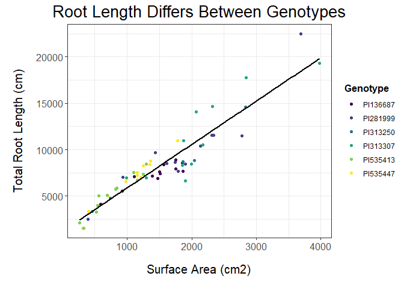

```r
#---------------------------------------------------------#
#                      graphs
#---------------------------------------------------------#


ggplot(data = Roots, aes(x = SurfArea, y = Length, colour = GT)) +
  geom_point() +
  geom_smooth(se= FALSE, method = lm, fullrange = T, colour = "Black")+
  theme_bw() +
  ggtitle("Root Length Differs Between Genotypes") +
  xlab("Surface Area (cm2)") + ylab("Total Root Length (cm)") +
  labs(colour = "Genotype") +
  theme(axis.text.x = element_text( size = 12),
        axis.text.y = element_text( size = 12),
        axis.title.x = element_text(size = 15, margin = margin(t = 15, r = 0, b = 10, l = 0)),
        axis.title.y = element_text(size = 15, margin = margin(t = 0, r = 15, b = 0, l = 10)),
        plot.title = element_text(size = 20, lineheight = 1.1, hjust = 0.5),
        legend.title = element_text( face = "bold",size = 12)) +
  scale_colour_viridis_d()
```